```r
library(readr)
bc = read_delim("r1.withq.barcodes", delim=" ")
library(dplyr)
grouped = bc %>% group_by(barcode, index) %>% summarise(count=n(), bcq=mean(barcodeq),
                                                        iq=mean(indexq))
```

# Summary stats

There are 65778 unique barcode-index pairs and of those 5838 are seen more than 10 times.

We can see below that there is are a small set of barcode-index pairs that are represented a high number of times.

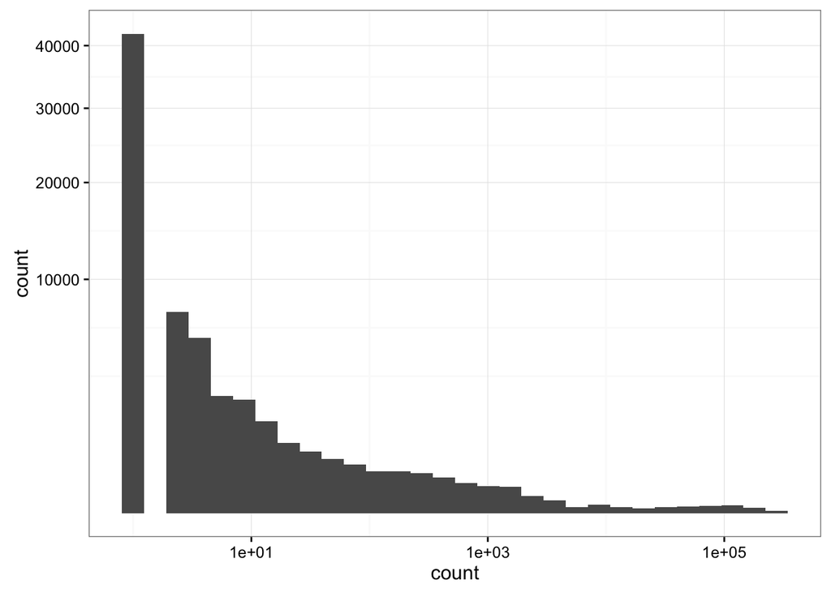

```r
library(ggplot2)
ggplot(grouped, aes(count)) + geom_histogram() + theme_bw() +
  scale_x_log10() + scale_y_sqrt()
```

# Known barcodes

Now we’ll mark up the barcode-index pair with whether or not these are some of the known sequences. The indexes we found correspond to the reverse complement column in the index file and the barcodes correspond to the sense column in the barcode file.

```r
kbc = read_csv("metadata/BC sequences.csv")
kin = read_csv("metadata/indexseqs.csv")
grouped$kin = grouped$index %in% kin$rc
grouped$kbc = grouped$barcode %in% kbc$sense
grouped$known = grouped$kin & grouped$kbc
grouped$known = ifelse(grouped$known, "known", "unknown")
known = subset(grouped, known == "known")
```

I wrote out the barcode-index pairs with counts, the mean of the barcode quality (bcq), the mean of the index quality (iq), whether or not the index is a known index (kin), whether or not the barcode is a known barcode (kin), and whether or not the barcode-index pair is expected (known).

This table is here All barcode index

```r
write.table(grouped, file="all-barcode-index-unfiltered.csv", col.names=TRUE, row.names=FALSE, quote=FALSE, sep=",")
```

Now we can see if we mark up the barcode-index pairs with whether or not they are from the known barcode and known index files, we find that there are only 940 barcode-index pairs.

If we plot the histograms separating out whether they are a known or unknown barcode-index pair, we can see that the known barcode-index pairs have many more reads associated with them than the unknown barcode-index pairs.

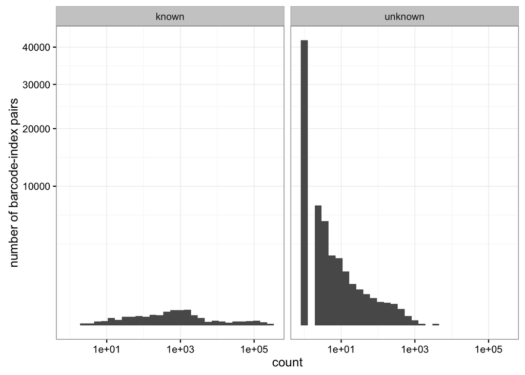

```r
library(ggplot2)
ggplot(grouped, aes(count)) + geom_histogram() + theme_bw() +
  facet_wrap(~known) +
  scale_x_log10() + scale_y_sqrt() +
  ylab("number of barcode-index pairs")
```

We can see that the PHRED quality of the known barcode-index pairs has a tight distribution:

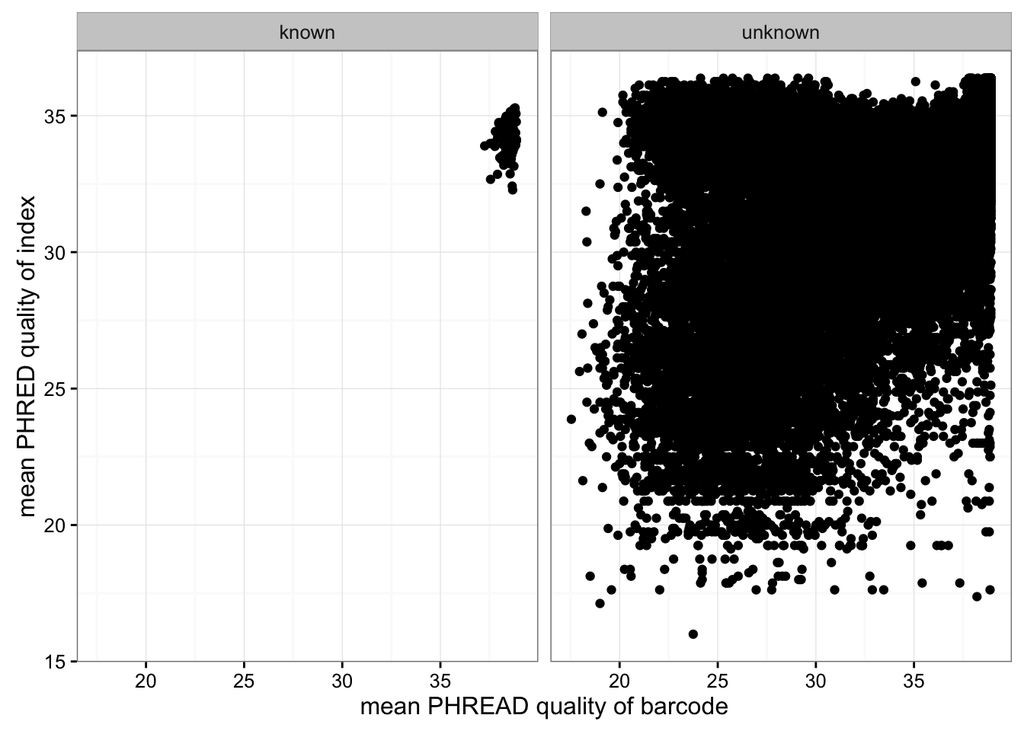

```r
ggplot(grouped, aes(bcq, iq)) + geom_point() + theme_bw() +
  facet_wrap(~known) +
  ylab("mean PHRED quality of index") +
  xlab("mean PHREAD quality of barcode")
```

# Barcodes per index

We’re expecting 2 to 3 barcodes per index, but we generally see more than that if we’re seeing 940 barcodes. How many per barcode?

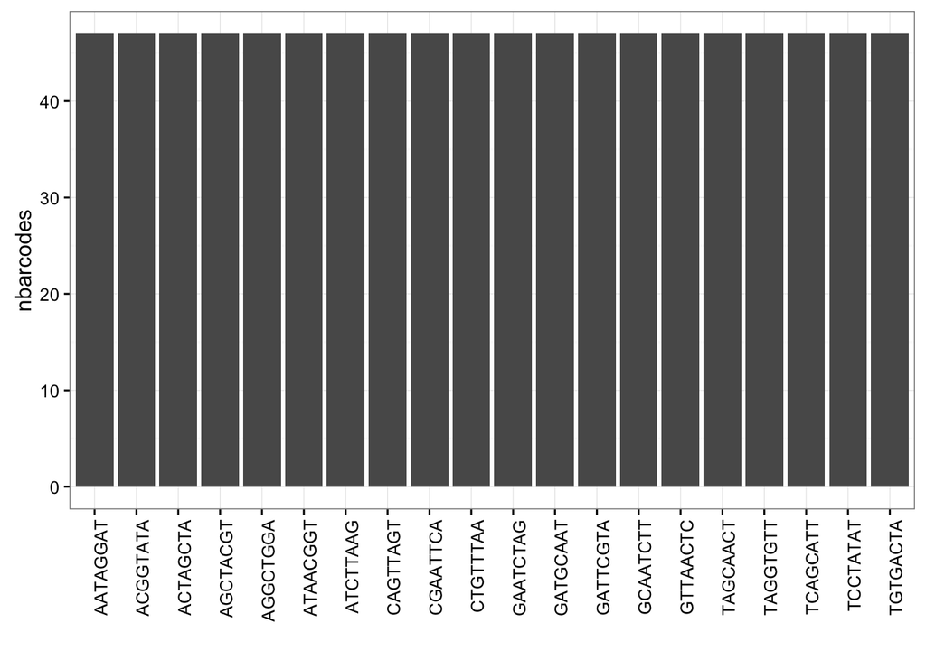

```r
barcode_per_index = known %>% group_by(index) %>% summarise(nbarcodes = n())
index_per_barcode = known %>% group_by(barcode) %>% summarise(nindex = n())
ggplot(barcode_per_index, aes(index, nbarcodes)) +
  geom_bar(stat='identity') +
  theme_bw() +
  theme(axis.text.x = element_text(angle = 90, hjust = 1)) +
  xlab("")
```

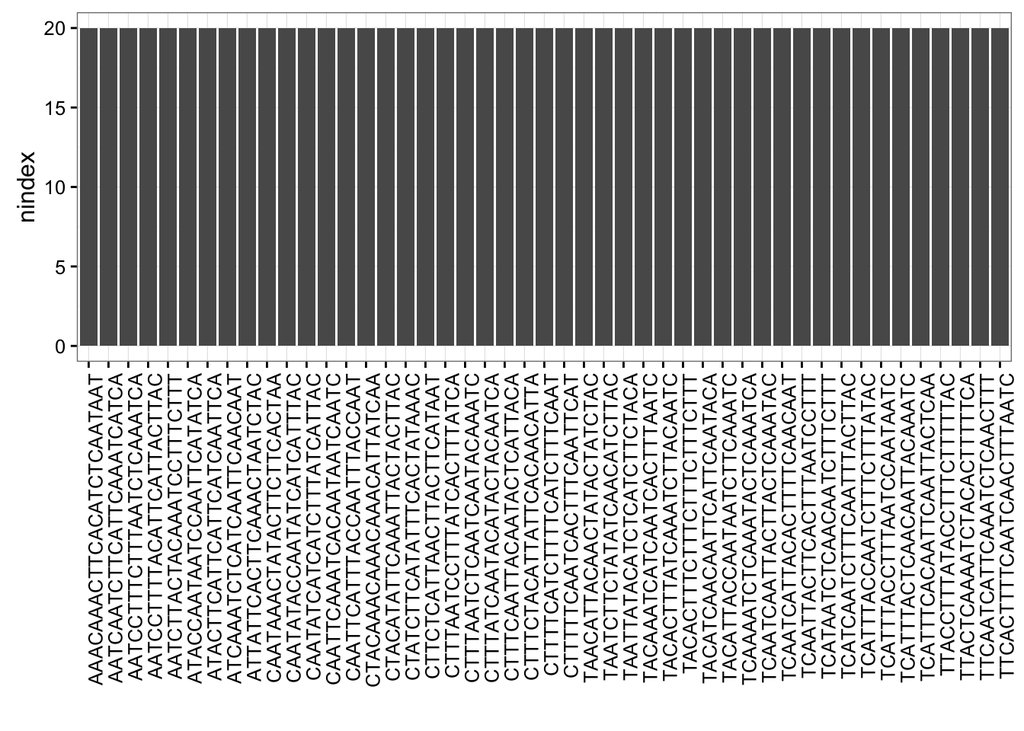

```r
ggplot(index_per_barcode, aes(barcode, nindex)) + geom_bar(stat='identity') +
  theme_bw() +
  theme(axis.text.x = element_text(angle = 90, hjust = 1)) +
  xlab("")
```

# Overrepresented barcodes

We see every index with every barcode at least once. Are some overrepresented?

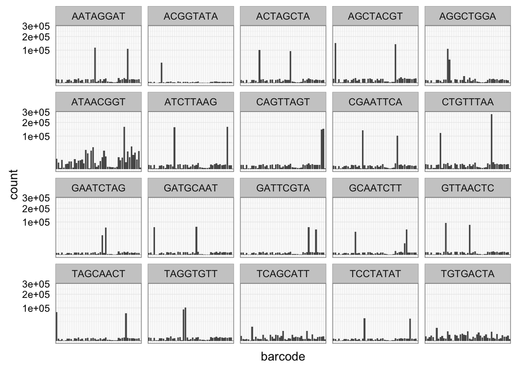

```r
ggplot(known, aes(barcode, count)) + facet_wrap(~index) + geom_bar(stat='identity') +
  scale_y_sqrt() +
  theme_bw() +
  theme(axis.ticks = element_blank(), axis.text.x = element_blank())
```

For some indexes it looks like yes, and for others no.

# Overepresented barcodes colored by quality

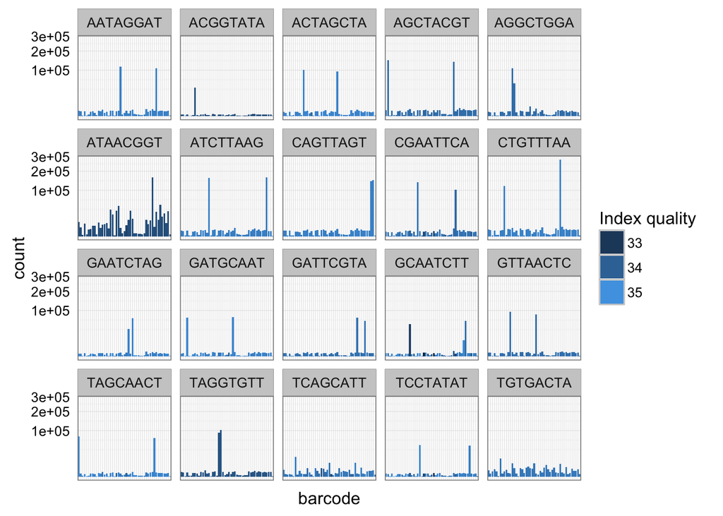

```r
ggplot(known, aes(barcode, count, fill=iq)) + facet_wrap(~index) +
  geom_bar(stat='identity') +
  scale_y_sqrt() +
  theme_bw() +
  theme(axis.ticks = element_blank(), axis.text.x = element_blank()) +
  guides(fill=guide_legend(title="Index quality"))
```

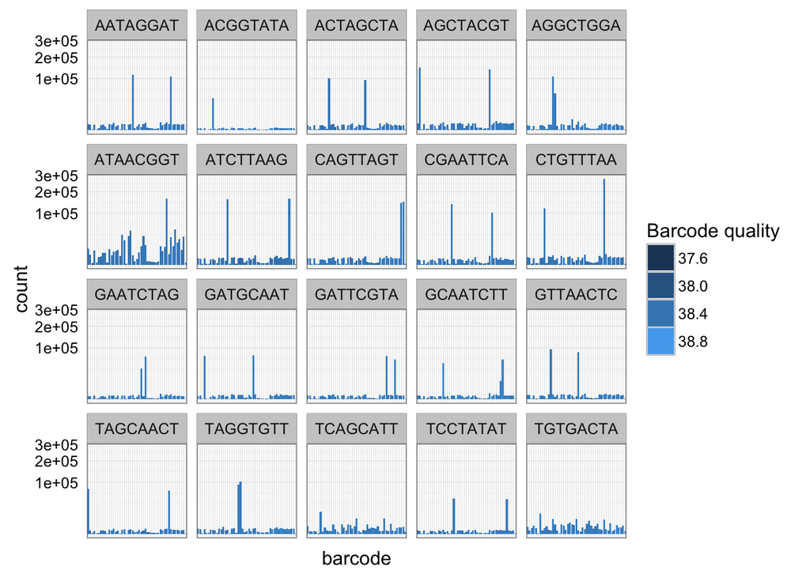

```r
ggplot(known, aes(barcode, count, fill=bcq)) + facet_wrap(~index) +
  geom_bar(stat='identity') +
  scale_y_sqrt() +
  theme_bw() +
  theme(axis.ticks = element_blank(), axis.text.x = element_blank()) +
  guides(fill=guide_legend(title="Barcode quality"))
```

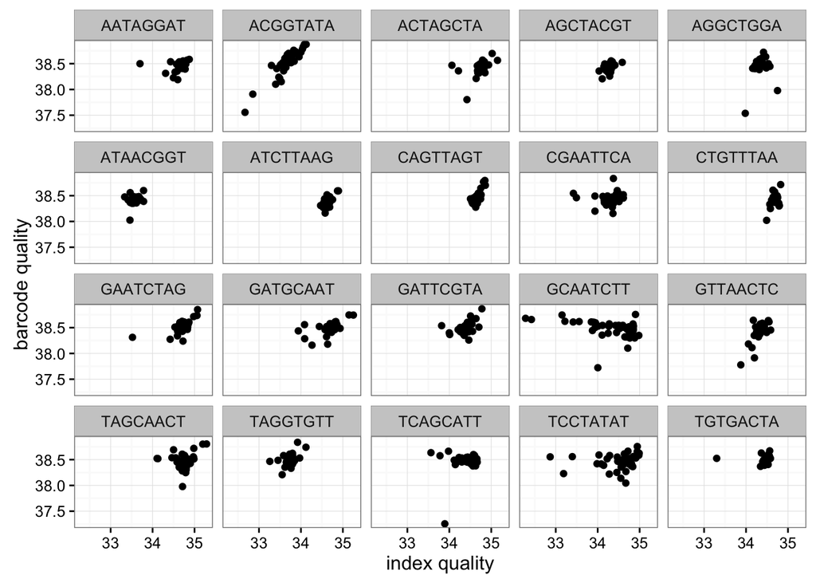

```r
ggplot(known, aes(iq, bcq)) + facet_wrap(~index) +
  geom_point() + xlab("index quality") +
  ylab("barcode quality") + theme_bw()
```

# Filtering for barcode pairs

Here I filtered by keeping only the barcodes for each index which were at least twice as prevalent as the average of the barcodes for that index. Then I filtered out all indexes that had more than 3 barcodes that passed that filter.

```r
filtered = known %>% group_by(index) %>%
  mutate(mcount = mean(count)) %>%
  filter(count > 2*mcount) %>% group_by(index) %>%
  mutate(nfiltered = n()) %>%
  filter(nfiltered < 4)
```

That leaves us with these:

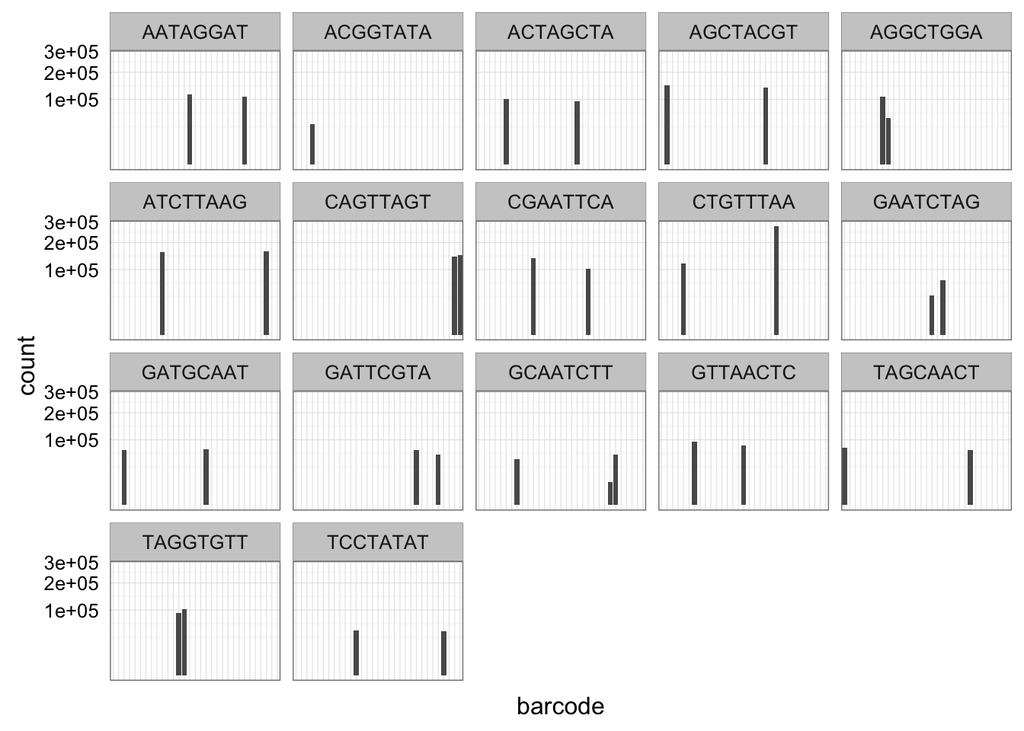

```r
ggplot(filtered, aes(barcode, count)) + facet_wrap(~index) +
  geom_bar(stat='identity') + scale_y_sqrt() +
  theme_bw() +
  theme(axis.ticks = element_blank(), axis.text.x = element_blank())
```

# Expected indexes

```r
expected = read_csv("metadata/expected-pairs.csv")
colnames(expected) = c("ebarcode", "eindex")
expected$pair = paste(expected$ebarcode, expected$eindex, sep=":")
filtered$pair = paste(filtered$barcode, filtered$index, sep=":")
filtered$expected = filtered$pair %in% expected$pair
```

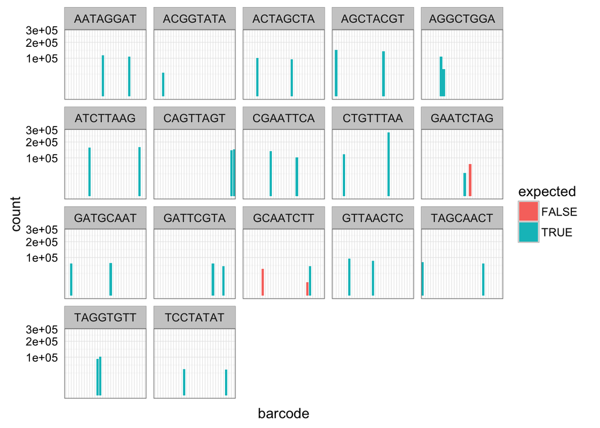

```r
ggplot(filtered, aes(barcode, count, fill=expected)) + facet_wrap(~index) +
  geom_bar(stat='identity') + scale_y_sqrt() +
  theme_bw() +
  theme(axis.ticks = element_blank(), axis.text.x = element_blank())
```

```r
output = filtered %>% select(barcode, index, count)
write.table(output, file="barcode-index.csv", col.names=TRUE,
            sep=",", quote=FALSE, row.names=FALSE)
```

# Expected on unfiltered list

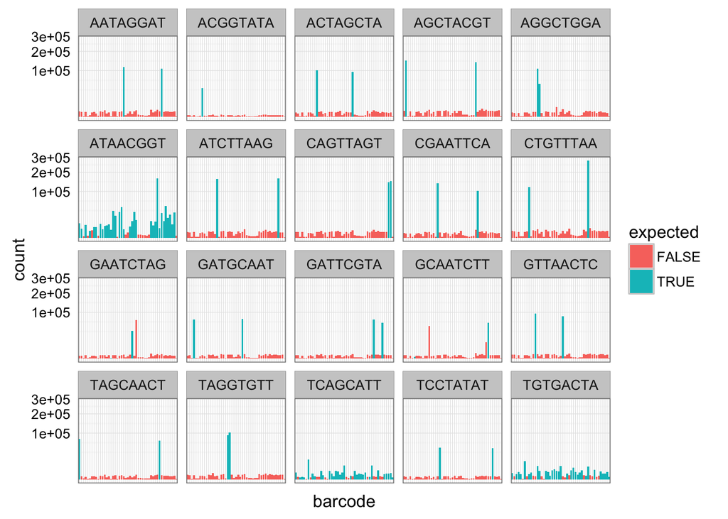

```r
known$pair = paste(known$barcode, known$index, sep=":")
known$expected = known$pair %in% expected$pair
ggplot(known, aes(barcode, count, fill=expected)) +
  facet_wrap(~index) + geom_bar(stat='identity') +
  scale_y_sqrt() +
  theme_bw() +
  theme(axis.ticks = element_blank(), axis.text.x = element_blank())
```

# 33 barcode mixes

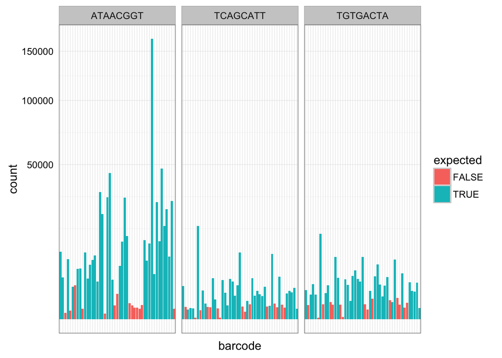

```r
index_mixes = c("ATAACGGT", "TCAGCATT", "TGTGACTA")
ggplot(subset(known, index %in% index_mixes),
       aes(barcode, count, fill=expected)) +
  facet_wrap(~index) + geom_bar(stat='identity') +
  scale_y_sqrt() +
  theme_bw() +
  theme(axis.ticks = element_blank(), axis.text.x = element_blank())
```

Coloring by barcode and index quality:

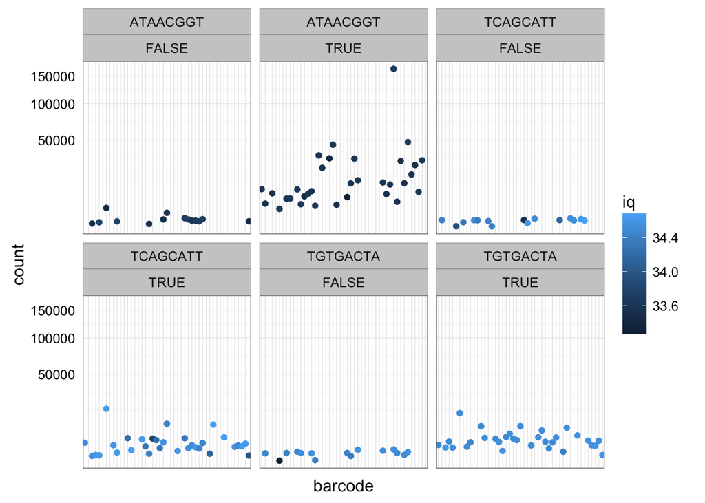

```r
ggplot(subset(known, index %in% index_mixes),
       aes(barcode, count, color=iq)) +
  facet_wrap(~index+expected) + geom_point() +
  scale_y_sqrt() +
  theme_bw() +
  theme(axis.ticks = element_blank(), axis.text.x = element_blank())
```

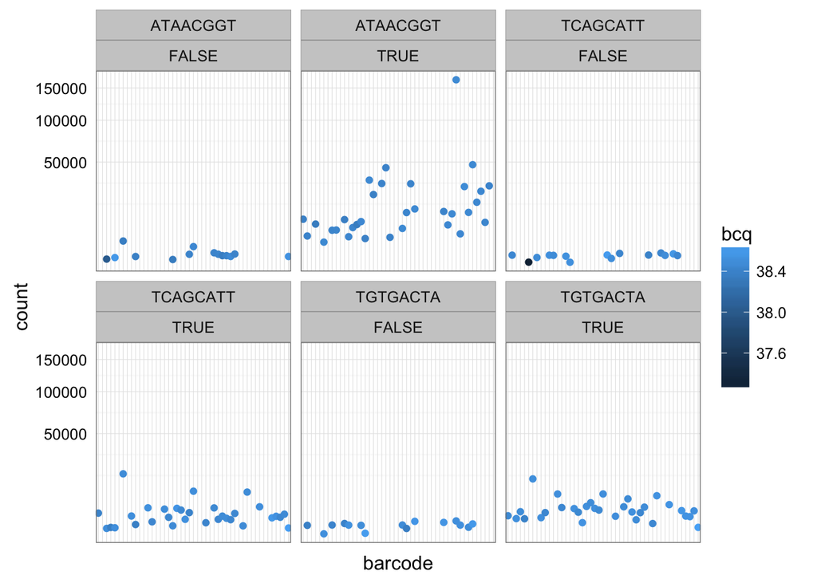

```r
ggplot(subset(known, index %in% index_mixes),
       aes(barcode, count, color=bcq)) +
  facet_wrap(~index+expected) + geom_point() +
  scale_y_sqrt() +
  theme_bw() +
  theme(axis.ticks = element_blank(), axis.text.x = element_blank())
```

Filtering out by barcode quality might help with some but doesn’t weed out all of the false positives.

# Output tables

```r
output = filtered %>% select(barcode, index, count, expected)
write.table(output, file="filtered-barcode-index.csv", col.names=TRUE,
            sep=",", quote=FALSE, row.names=FALSE)
output = known %>% select(barcode, index, count, expected)
write.table(output, file="unfiltered-barcode-index.csv", col.names=TRUE,
            sep=",", quote=FALSE, row.names=FALSE)
```

filtered-barcode-index.csv

unfiltered-barcode-index.csv

I included an example of a CSV file of the expected pairs that is much easier to work with:

expected-pairs.csv